# Alpha beta gamma by Site

Kelli Feeser

2025-03-24

[Back to Home](https://kellifeeser.github.io/ksu-paired-amplicon-workflow/index.html)

Document last updated: 2025-03-24

# Set-up

## 0.1 load packages

## 0.2 load rds

# 1 Regional species pool: 𝛄 - Gamma diversity of sites ($\gamma_{site}$) and species richness ($\alpha_{site}$)

## Calculate site gamma ($\gamma_{site}$)

## 1.1 BvF summary stats

Table 1.1: Summary of Alpha and Gamma Diversity Metrics by Kingdom

| Metric | Bacteria | B > F | Fungi |
| --- | --- | --- | --- |
| *γ<sub>site</sub> diversity* |  |  |  |
| min | 2505 | > | 256 |
| max | 8620 | > | 1442 |
| mean ± sd | 5328 ± 1858 | > | 877 ± 348 |
| *Sample-level α* |  |  |  |
| min | 187 | > | 41 |
| max | 1941 | > | 311 |
| mean ± sd | 1113 ± 311 | > | 146 ± 53 |
| *Site mean α* |  |  |  |
| min | 712 | > | 71 |
| max | 1712 | > | 219 |
| mean ± sd | 1082 ± 250 | > | 143 ± 52 |

## 1.2 Tables of gamma and alpha diversity metrics with derived measures by Site for Bacteria and Fungi

### 1.2.1 Bacteria-Archaea

```r
Bac_gamma_Site3 %>%
  kbl(caption = "Gamma diversity of sites: bacteria",
            align = 'c',
      # col.names = c("Number of OTUs","Number of samples")
      # ,format.args = format(list(big.mark = ',', digit))
      ) %>%
  kable_styling() %>%
  scroll_box(width = "90%", height = "250px")
```

Table 1.2: Gamma diversity of sites: bacteria

|  | Gamma (# total unique OTUs) | n (# of samples per site) | # of grass hosts per site | Gamma / n | Observed mean 𝝰 | mean prop. of gamma detected per sample | SD prop. of gamma detected per sample |
| --- | --- | --- | --- | --- | --- | --- | --- |
| BLM | 4,689 | 23 | 2 | 203.9 | 924.7 | 0.197 | 0.029 |
| BNP | 4,547 | 15 | 2 | 303.1 | 964.1 | 0.212 | 0.033 |
| CAD | 8,620 | 38 | 4 | 226.8 | 1,419.1 | 0.165 | 0.031 |
| CNF | 5,427 | 27 | 3 | 201 | 931.7 | 0.172 | 0.041 |
| CPR | 2,719 | 11 | 1 | 247.2 | 814.4 | 0.3 | 0.045 |
| DMT | 5,801 | 26 | 3 | 223.1 | 942.7 | 0.163 | 0.022 |
| FCP | 6,362 | 27 | 3 | 235.6 | 1,154.5 | 0.181 | 0.026 |
| FMT | 4,076 | 15 | 2 | 271.7 | 922.6 | 0.226 | 0.026 |
| GMT | 4,362 | 19 | 2 | 229.6 | 1,010.6 | 0.232 | 0.034 |
| GNF | 2,711 | 7 | 1 | 387.3 | 964.9 | 0.356 | 0.03 |
| HAR | 6,631 | 37 | 4 | 179.2 | 1,058.9 | 0.16 | 0.028 |
| HPG | 4,043 | 15 | 2 | 269.5 | 1,061.3 | 0.263 | 0.035 |
| KAE | 6,909 | 32 | 3 | 215.9 | 875.5 | 0.127 | 0.061 |
| KNZ | 7,892 | 42 | 4 | 187.9 | 1,390.3 | 0.176 | 0.019 |
| LAR | 4,516 | 27 | 3 | 167.3 | 785.2 | 0.174 | 0.032 |
| LBJ | 7,876 | 34 | 3 | 231.6 | 1,217.4 | 0.155 | 0.026 |
| NWP | 5,964 | 20 | 2 | 298.2 | 1,325.1 | 0.222 | 0.031 |
| ONF | 5,569 | 22 | 2 | 253.1 | 1,127.8 | 0.203 | 0.034 |
| RNF | 2,517 | 6 | 1 | 419.5 | 1,007.5 | 0.4 | 0.055 |
| SEV | 2,505 | 10 | 2 | 250.5 | 712.3 | 0.284 | 0.031 |
| SFA | 5,456 | 10 | 1 | 545.6 | 1,471.5 | 0.27 | 0.021 |
| UHC | 8,020 | 21 | 2 | 381.9 | 1,711.6 | 0.213 | 0.021 |

### 1.2.2 Fungi

```r
Fun_gamma_Site3 %>%
  kbl(caption = "Gamma diversity of sites: fungi",
            align = 'c',
      # col.names = c("Number of OTUs","Number of samples")

      # ,format.args = format(list(big.mark = ',', digit))
      ) %>%
  kable_styling() %>%
  scroll_box(width = "90%", height = "250px")
```

Table 1.3: Gamma diversity of sites: fungi

|  | Gamma (# total unique OTUs) | n (# of samples per site) | # of grass hosts per site | Gamma / n | Observed mean 𝝰 | mean prop. of gamma detected per sample | SD prop. of gamma detected per sample |
| --- | --- | --- | --- | --- | --- | --- | --- |
| BLM | 983 | 23 | 2 | 42.7 | 181.3 | 0.184 | 0.029 |
| BNP | 633 | 15 | 2 | 42.2 | 83.2 | 0.131 | 0.04 |
| CAD | 1,341 | 38 | 4 | 35.3 | 120 | 0.09 | 0.021 |
| CNF | 923 | 27 | 3 | 34.2 | 173.3 | 0.188 | 0.019 |
| CPR | 430 | 11 | 1 | 39.1 | 94.1 | 0.219 | 0.031 |
| DMT | 1,044 | 26 | 3 | 40.2 | 93.3 | 0.089 | 0.024 |
| FCP | 1,169 | 27 | 3 | 43.3 | 120.5 | 0.103 | 0.03 |
| FMT | 522 | 15 | 2 | 34.8 | 71.4 | 0.137 | 0.023 |
| GMT | 646 | 19 | 2 | 34 | 189 | 0.293 | 0.022 |
| GNF | 256 | 7 | 1 | 36.6 | 74 | 0.289 | 0.059 |
| HAR | 1,315 | 37 | 4 | 35.5 | 129.4 | 0.098 | 0.025 |
| HPG | 717 | 15 | 2 | 47.8 | 165.3 | 0.23 | 0.052 |
| KAE | 1,202 | 32 | 3 | 37.6 | 119.5 | 0.099 | 0.018 |
| KNZ | 1,337 | 42 | 4 | 31.8 | 141 | 0.105 | 0.02 |
| LAR | 694 | 27 | 3 | 25.7 | 90.8 | 0.131 | 0.027 |
| LBJ | 1,442 | 34 | 3 | 42.4 | 218.6 | 0.152 | 0.025 |
| NWP | 1,007 | 20 | 2 | 50.4 | 219.3 | 0.218 | 0.021 |
| ONF | 1,068 | 22 | 2 | 48.5 | 203.3 | 0.19 | 0.019 |
| RNF | 443 | 6 | 1 | 73.8 | 179.7 | 0.406 | 0.035 |
| SEV | 379 | 10 | 2 | 37.9 | 73.5 | 0.194 | 0.055 |
| SFA | 817 | 10 | 1 | 81.7 | 188.4 | 0.231 | 0.051 |
| UHC | 936 | 21 | 2 | 44.6 | 212 | 0.226 | 0.024 |

# 2 Mean beta dissimilarities by Site

## 2.1 Background

If two groups of sampling units are truly different (e.g. in their species composition), then average of the within-group compositional dissimilarities should be less than the average of the dissimilarities between two random collection of sampling units drawn from the entire population.

**Within-group (Site) values should be << the overall/global average if true difference in location (differences in mean *or* dispersion) exists.**

This difference may be one of location (differences in mean) or one of spread (differences in within-group distance). That is, it may find a significant difference between two groups simply because one of those groups has a greater dissimilarities among its sampling units.

## 2.2 Bacterial vs. fungal mean dissimilarity by Site

```r
# Extract summaries
sum_bac <- summary(md_bwc_Site)
sum_fun <- summary(md_Fwc_Site)

# Extract key values
mean_bac_within <- round(sum_bac$W, 4)
mean_fun_within <- round(sum_fun$W, 4)
mean_bac_between <- round(sum_bac$B, 4)
mean_fun_between <- round(sum_fun$B, 4)
mean_bac_overall <- round(sum_bac$D, 4)
mean_fun_overall <- round(sum_fun$D, 4)

# Comparison symbol
compare_symbol <- function(bac, fun, tol = 1e-6) {
  if (abs(bac - fun) < tol) {
    "="
  } else if (bac > fun) {
    ">"
  } else {
    "<"
  }
}

comp_col <- c(
  compare_symbol(mean_bac_within, mean_fun_within),
  compare_symbol(mean_bac_between, mean_fun_between),
  compare_symbol(mean_bac_overall, mean_fun_overall)
)

# Build comparison table
summary_table <- tibble(
  Metric = c("Mean within-group", "Mean between-group", "Overall mean"),
  Bacteria = c(mean_bac_within, mean_bac_between, mean_bac_overall),
  `B < F` = comp_col,
  Fungi = c(mean_fun_within, mean_fun_between, mean_fun_overall)
)

# Print side-by-side comparison table
summary_table %>%
  kable(format = "html", caption = "Comparison of bacterial and fungal mean within- and between-Site Sørensen pairwise dissimilarities") %>%
  kable_styling(bootstrap_options = c("striped", "condensed"), full_width = FALSE) %>%
  column_spec(2:4, extra_css = "text-align: center;")
```

Table 2.1: Comparison of bacterial and fungal mean within- and between-Site Sørensen pairwise dissimilarities

| Metric | Bacteria | B < F | Fungi |
| --- | --- | --- | --- |
| Mean within-group | 0.5661 | < | 0.6539 |
| Mean between-group | 0.6961 | < | 0.8302 |
| Overall mean | 0.6892 | < | 0.8209 |

*Between-Kingdom Comparisons*

Among all samples, fungi had the higher overall mean Sørensen dissimilarity value across all sites and samples, with a value of 0.8209 compared to 0.6892 for bacteria.

Within-site dissimilarity (0.6539 for fungi, 0.5661 for bacteria) was greater for fungi, suggesting higher spatial turnover or within-site heterogeneity for the fungal community.

*Among-Kingdom Comparisons*

For **bacteria**, the within-group dissimilarity (0.5661) was lower than the overall average (0.6892), indicating that samples from the same site were more compositionally similar than samples across all sites. This pattern suggests that site identity explains some of the bacterial compositional variation.

Similarly, for **fungi**, within-site dissimilarity was lower than the overall dissimilarity, suggesting that fungal samples from the same site were more similar to each other compared to the global average.

In both domains, a **between-group mean dissimilarity** (0.6961 for bacteria, 0.8302 for fungi) greater than the within-group value suggests that Site did influence the presence/absence-based of compositional structure of communities — either due to differences in **mean community composition** (location) or **dispersion** (variability within sites).

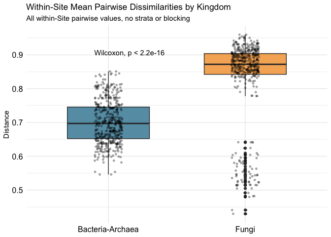

## 2.3 strat by F1 vs non-F1 [in-progress]

# 3 Beta dispersion (variance) by site

Implementation of Marti Anderson’s PERMDISP2 procedure for the analysis of multivariate homogeneity of group dispersions (variances). `vegan::betadisper()` is a multivariate analogue of Levene’s test for homogeneity of variances.

## Calculate betadisp dispersions by site

```r
# Fun
Fun_wc_sorensen_distmat <- as.matrix(sor.dist.list$Fun_wholecommunity)

Fun_wc_sorensen_dist<-as.dist(Fun_wc_sorensen_distmat)

## Calculate multivariate dispersions
betadisp_Site_Fun_addC <- betadisper(Fun_wc_sorensen_dist,
                            group = phylo2vegan_sd(Fun_wholecommunity)$Site,
                            type = "median", # type = "median" (distance from each sample unit to the spatial median of its group)
                            bias.adjust = T, # adjust for small sample bias in beta div estimates?
                            sqrt.dist = FALSE,
                            add = "lingoes")

# Bac
Bac_wc_sorensen_distmat <- as.matrix(beta.pair(decostand(phylo2vegan_OTU(Bac_wholecommunity), method = "pa"), index.family = "sorensen")$beta.sor)

Bac_wc_sorensen_dist<-as.dist(Bac_wc_sorensen_distmat)

## Calculate multivariate dispersions
betadisp_Site_Bac_addC <- betadisper(Bac_wc_sorensen_dist,
                            group = phylo2vegan_sd(Bac_wholecommunity)$Site,
                            type = "median", # type = "median" (distance from each sample unit to the spatial median of its group)
                            bias.adjust = T, # adjust for small sample bias in beta div estimates?
                            sqrt.dist = FALSE,
                            add = "lingoes")
```

```r
perform_anova_betadisper <- function(betadisper_object, grouping) {

  # Perform ANOVA
  anova_result <- anova(betadisper_object)

  tidy_aov <- tidy(anova_result)
  tidy_df <- as.data.frame(tidy_aov)

  tidy_df$term[1] <- paste0(grouping)

  sum_squares_regression <- tidy_df$sumsq[1]
  sum_squares_residuals <- tidy_df$sumsq[2]

  R_squared <- sum_squares_regression /
            (sum_squares_regression + sum_squares_residuals)*100

  tidier_df <- data.frame(Term = character(),df = numeric(),
                          SumSq = numeric(),MeanSq = numeric(),
                          F.statistic = numeric(),
                          R_squared = numeric(),p.value = character(),
                          stringsAsFactors = FALSE)

  tidier_df[1,"Term"] <- tidy_df$term[1]
  tidier_df[2,"Term"] <- tidy_df$term[2]
  tidier_df[1:2,2] <- (tidy_df$df)[1:2]
  tidier_df$SumSq <- round(tidy_df$sumsq[1:2],2)
  tidier_df$MeanSq <- round(tidy_df$meansq[1:2],3)
  tidier_df$F.statistic <- round(tidy_df$statistic,2)
  tidier_df[1,"R_squared"] <- round(R_squared,2)
  tidier_df[2,"R_squared"] <- 100-(round(R_squared,2))
  tidier_df[1,"P.value"] <- prettyNum(tidy_df$p.value[1],digits=2)

  # Return ANOVA results for the specified taxa_of_interest
  return(tidier_df)
}
```

## 3.1 Results: Homogeneity of multivariate dispersions - site dispersions

### 3.1.1 Bac

range of site dispersions:

```r
summary(betadisp_Site_Bac_addC$group.distances)
```

```
##    Min. 1st Qu.  Median    Mean 3rd Qu.    Max.
##  0.3596  0.3912  0.4175  0.4162  0.4360  0.5076
```

```r
betadisp_Site_Bac_addC
```

```
##
##  Homogeneity of multivariate dispersions
##
## Call: betadisper(d = Bac_wc_sorensen_dist, group =
## phylo2vegan_sd(Bac_wholecommunity)$Site, type = "median", bias.adjust = T,
## sqrt.dist = FALSE, add = "lingoes")
##
## No. of Positive Eigenvalues: 482
## No. of Negative Eigenvalues: 0
##
## Average distance to median:
##    BLM    BNP    CAD    CNF    CPR    DMT    FCP    FMT    GMT    GNF    HAR    HPG    KAE
## 0.4160 0.4380 0.4190 0.4509 0.3763 0.4599 0.4302 0.4410 0.3890 0.3820 0.4251 0.3778 0.5076
##    KNZ    LAR    LBJ    NWP    ONF    RNF    SEV    SFA    UHC
## 0.3898 0.4232 0.4421 0.3957 0.4041 0.3596 0.4091 0.4193 0.4011
##
## Eigenvalues for PCoA axes:
## (Showing 8 of 482 eigenvalues)
##  PCoA1  PCoA2  PCoA3  PCoA4  PCoA5  PCoA6  PCoA7  PCoA8
## 17.234  9.227  5.236  5.106  3.033  2.479  1.895  1.831
```

#### Perform ANOVA

probably removing in favor of perm F test (following)

`betadisp_Site_Bac.aov <- perform_anova_betadisper(betadisp_Site_Bac_addC, "Site")`

```r
betadisp_Site_Bac.aov<-perform_anova_betadisper(betadisp_Site_Bac_addC, "Site")
```

```r
betadisp_Site_Bac.aov %>% kbl() %>% kable_styling()
```

[output not shown]

#### 3.1.1.1 Permutation test for F with post-hoc Tukey’s HSD

`vegan::permutest(betadisp_Site_Bac_addC, permutations = 999)`

```
##
## Permutation test for homogeneity of multivariate dispersions
## Permutation: free
## Number of permutations: 999
##
## Response: Distances
##            Df  Sum Sq   Mean Sq      F N.Perm Pr(>F)
## Groups     21 0.50316 0.0239599 14.104    999  0.001 ***
## Residuals 462 0.78483 0.0016988
## ---
## Signif. codes:  0 '***' 0.001 '**' 0.01 '*' 0.05 '.' 0.1 ' ' 1
```

Impact of site on explainable variability of beta dispersions:

Permuted $F$ = 14.104

Calculated $R^2$ = 0.391

Site had a significant influence on bacterial community variance, explaining a calculated 39.1% of the beta dispersion variability (permuted $F$ = 14.104).

**Post-hoc: compute Tukey HSD**

`stats::TukeyHSD(betadisp_Site_Bac_addC, ordered = T)`

```r
## Tukey's Honest Significant Differences
(betadisp_Site_Bac_addC.HSD <- TukeyHSD(betadisp_Site_Bac_addC, ordered = T, conf.level = 0.95))
bdHSDBacs<-subset(as.data.frame(betadisp_Site_Bac_addC.HSD$group),`p adj` < 0.05)
# plot(betadisp_Site_Bac_addC.HSD)
```

```r
bdHSDBacs %>%
  kbl(caption = "Bacteria: sites with significantly different beta dispersion, subset to p.adj < 0.05 (Tukey HSD)",
            align = 'c',
      digits = c(3,3,3,4)
      # col.names = c("Number of OTUs","Number of samples")
      # format.args = format(list(big.mark = ',', digit))
      ) %>%
  kable_styling() %>%
  scroll_box(width = "60%", height = "350px")
```

Table 3.1: Bacteria: sites with significantly different beta dispersion, subset to p.adj < 0.05 (Tukey HSD)

|  | diff | lwr | upr | p adj |
| --- | --- | --- | --- | --- |
| FCP-RNF | 0.071 | 0.003 | 0.138 | 0.0272 |
| BNP-RNF | 0.078 | 0.006 | 0.150 | 0.0166 |
| FMT-RNF | 0.081 | 0.009 | 0.153 | 0.0093 |
| LBJ-RNF | 0.083 | 0.017 | 0.148 | 0.0016 |
| CNF-RNF | 0.091 | 0.024 | 0.159 | 0.0003 |
| DMT-RNF | 0.100 | 0.033 | 0.168 | 0.0000 |
| KAE-RNF | 0.148 | 0.082 | 0.214 | 0.0000 |
| FCP-CPR | 0.054 | 0.001 | 0.107 | 0.0434 |
| BNP-CPR | 0.062 | 0.003 | 0.121 | 0.0300 |
| FMT-CPR | 0.065 | 0.006 | 0.124 | 0.0153 |
| LBJ-CPR | 0.066 | 0.014 | 0.117 | 0.0011 |
| CNF-CPR | 0.075 | 0.021 | 0.128 | 0.0001 |
| DMT-CPR | 0.084 | 0.030 | 0.137 | 0.0000 |
| KAE-CPR | 0.131 | 0.079 | 0.183 | 0.0000 |
| HAR-HPG | 0.047 | 0.002 | 0.093 | 0.0322 |
| FCP-HPG | 0.052 | 0.004 | 0.100 | 0.0157 |
| BNP-HPG | 0.060 | 0.006 | 0.115 | 0.0132 |
| FMT-HPG | 0.063 | 0.009 | 0.118 | 0.0060 |
| LBJ-HPG | 0.064 | 0.018 | 0.110 | 0.0001 |
| CNF-HPG | 0.073 | 0.025 | 0.121 | 0.0000 |
| DMT-HPG | 0.082 | 0.034 | 0.130 | 0.0000 |
| KAE-HPG | 0.130 | 0.083 | 0.176 | 0.0000 |
| CNF-GNF | 0.069 | 0.006 | 0.132 | 0.0162 |
| DMT-GNF | 0.078 | 0.014 | 0.141 | 0.0023 |
| KAE-GNF | 0.126 | 0.063 | 0.188 | 0.0000 |
| FMT-GMT | 0.052 | 0.001 | 0.104 | 0.0434 |
| LBJ-GMT | 0.053 | 0.010 | 0.096 | 0.0017 |
| CNF-GMT | 0.062 | 0.017 | 0.107 | 0.0002 |
| DMT-GMT | 0.071 | 0.026 | 0.116 | 0.0000 |
| KAE-GMT | 0.119 | 0.075 | 0.162 | 0.0000 |
| HAR-KNZ | 0.035 | 0.002 | 0.069 | 0.0268 |
| FCP-KNZ | 0.040 | 0.004 | 0.077 | 0.0141 |
| BNP-KNZ | 0.048 | 0.003 | 0.093 | 0.0197 |
| FMT-KNZ | 0.051 | 0.006 | 0.096 | 0.0077 |
| LBJ-KNZ | 0.052 | 0.018 | 0.087 | 0.0000 |
| CNF-KNZ | 0.061 | 0.024 | 0.098 | 0.0000 |
| DMT-KNZ | 0.070 | 0.033 | 0.107 | 0.0000 |
| KAE-KNZ | 0.118 | 0.083 | 0.153 | 0.0000 |
| LBJ-NWP | 0.046 | 0.004 | 0.088 | 0.0131 |
| CNF-NWP | 0.055 | 0.011 | 0.099 | 0.0014 |
| DMT-NWP | 0.064 | 0.020 | 0.109 | 0.0001 |
| KAE-NWP | 0.112 | 0.069 | 0.154 | 0.0000 |
| CNF-UHC | 0.050 | 0.007 | 0.093 | 0.0071 |
| DMT-UHC | 0.059 | 0.015 | 0.103 | 0.0003 |
| KAE-UHC | 0.106 | 0.065 | 0.148 | 0.0000 |
| CNF-ONF | 0.047 | 0.004 | 0.090 | 0.0153 |
| DMT-ONF | 0.056 | 0.013 | 0.099 | 0.0008 |
| KAE-ONF | 0.103 | 0.062 | 0.145 | 0.0000 |
| KAE-SEV | 0.098 | 0.045 | 0.152 | 0.0000 |
| DMT-BLM | 0.044 | 0.001 | 0.087 | 0.0354 |
| KAE-BLM | 0.092 | 0.051 | 0.132 | 0.0000 |
| DMT-CAD | 0.041 | 0.003 | 0.079 | 0.0193 |
| KAE-CAD | 0.089 | 0.053 | 0.124 | 0.0000 |
| KAE-SFA | 0.088 | 0.034 | 0.142 | 0.0000 |
| KAE-LAR | 0.084 | 0.045 | 0.123 | 0.0000 |
| KAE-HAR | 0.082 | 0.047 | 0.118 | 0.0000 |
| KAE-FCP | 0.077 | 0.038 | 0.116 | 0.0000 |
| KAE-BNP | 0.070 | 0.023 | 0.116 | 0.0000 |
| KAE-FMT | 0.067 | 0.020 | 0.113 | 0.0001 |
| KAE-LBJ | 0.065 | 0.029 | 0.102 | 0.0000 |
| KAE-CNF | 0.057 | 0.018 | 0.096 | 0.0000 |
| KAE-DMT | 0.048 | 0.008 | 0.087 | 0.0029 |

Of a total of 231 pairwise site-site comparisons, only 62 were significantly different.

### Fun

range of site dispersions:

```r
summary(betadisp_Site_Fun_addC$group.distances)
```

```
##    Min. 1st Qu.  Median    Mean 3rd Qu.    Max.
##  0.5467  0.5955  0.6675  0.6628  0.7292  0.7698
```

```r
betadisp_Site_Fun_addC
```

```
##
##  Homogeneity of multivariate dispersions
##
## Call: betadisper(d = Fun_wc_sorensen_dist, group =
## phylo2vegan_sd(Fun_wholecommunity)$Site, type = "median", bias.adjust = T,
## sqrt.dist = FALSE, add = "lingoes")
##
## No. of Positive Eigenvalues: 482
## No. of Negative Eigenvalues: 0
##
## Average distance to median:
##    BLM    BNP    CAD    CNF    CPR    DMT    FCP    FMT    GMT    GNF    HAR    HPG    KAE
## 0.6057 0.7496 0.7428 0.5813 0.6723 0.7698 0.7479 0.7450 0.5467 0.6628 0.7317 0.6494 0.7217
##    KNZ    LAR    LBJ    NWP    ONF    RNF    SEV    SFA    UHC
## 0.7067 0.6819 0.5967 0.5859 0.5951 0.5836 0.7140 0.6288 0.5630
##
## Eigenvalues for PCoA axes:
## (Showing 8 of 482 eigenvalues)
##  PCoA1  PCoA2  PCoA3  PCoA4  PCoA5  PCoA6  PCoA7  PCoA8
## 27.298 11.999  8.004  5.871  4.597  4.072  3.594  3.280
```

#### 3.1.1.2 Permutation test for F with post-hoc Tukey’s HSD

`vegan::permutest(betadisp_Site_Fun_addC, permutations = 999)`

```r
## Permutation test for F
betadisp_Site_Fun.pmod <- permutest(betadisp_Site_Fun_addC, permutations = 999, pairwise = F)
bdr2Fun<-prettyNum(betadisp_Site_Fun.pmod$tab$`Sum Sq`[1]/(sum(betadisp_Site_Fun.pmod$tab$`Sum Sq`)),digits=3)
```

```r
betadisp_Site_Fun.pmod
```

```
##
## Permutation test for homogeneity of multivariate dispersions
## Permutation: free
## Number of permutations: 999
##
## Response: Distances
##            Df  Sum Sq  Mean Sq      F N.Perm Pr(>F)
## Groups     21 2.46260 0.117267 68.943    999  0.001 ***
## Residuals 462 0.78583 0.001701
## ---
## Signif. codes:  0 '***' 0.001 '**' 0.01 '*' 0.05 '.' 0.1 ' ' 1
```

Impact of site on explainable variability of beta dispersions:

Permuted $F$ = 68.943

Calculated $R^2$ = 0.758

Site had a very large influence on fungal community variance, explaining a calculated 75.8% of the beta dispersion variability (permuted $F$ = 68.943).

**Post-hoc: compute Tukey HSD**

`stats::TukeyHSD(betadisp_Site_Fun_addC, ordered = T)`

```r
## Tukey's Honest Significant Differences
(betadisp_Site_Fun_addC.HSD <- TukeyHSD(betadisp_Site_Fun_addC, ordered = T, conf.level = 0.95))
bdHSDFuns<-subset(as.data.frame(betadisp_Site_Fun_addC.HSD$group),`p adj` < 0.05)
# plot(betadisp_Site_Fun_addC.HSD)
```

Table 3.2: Fungi: sites with significantly different beta dispersion, subset to p.adj < 0.05 (Tukey HSD)

|  | diff | lwr | upr | p adj |
| --- | --- | --- | --- | --- |
| ONF-GMT | 0.048 | 0.002 | 0.095 | 0.0320 |
| LBJ-GMT | 0.050 | 0.007 | 0.093 | 0.0054 |
| BLM-GMT | 0.059 | 0.013 | 0.105 | 0.0011 |
| SFA-GMT | 0.082 | 0.024 | 0.140 | 0.0001 |
| HPG-GMT | 0.103 | 0.051 | 0.154 | 0.0000 |
| GNF-GMT | 0.116 | 0.050 | 0.182 | 0.0000 |
| CPR-GMT | 0.126 | 0.069 | 0.182 | 0.0000 |
| LAR-GMT | 0.135 | 0.091 | 0.180 | 0.0000 |
| KNZ-GMT | 0.160 | 0.119 | 0.201 | 0.0000 |
| SEV-GMT | 0.167 | 0.109 | 0.226 | 0.0000 |
| KAE-GMT | 0.175 | 0.132 | 0.218 | 0.0000 |
| HAR-GMT | 0.185 | 0.143 | 0.227 | 0.0000 |
| CAD-GMT | 0.196 | 0.154 | 0.238 | 0.0000 |
| FMT-GMT | 0.198 | 0.147 | 0.250 | 0.0000 |
| FCP-GMT | 0.201 | 0.157 | 0.246 | 0.0000 |
| BNP-GMT | 0.203 | 0.151 | 0.254 | 0.0000 |
| DMT-GMT | 0.223 | 0.178 | 0.268 | 0.0000 |
| SFA-UHC | 0.066 | 0.009 | 0.123 | 0.0073 |
| HPG-UHC | 0.086 | 0.036 | 0.137 | 0.0000 |
| GNF-UHC | 0.100 | 0.035 | 0.165 | 0.0000 |
| CPR-UHC | 0.109 | 0.054 | 0.165 | 0.0000 |
| LAR-UHC | 0.119 | 0.076 | 0.162 | 0.0000 |
| KNZ-UHC | 0.144 | 0.104 | 0.184 | 0.0000 |
| SEV-UHC | 0.151 | 0.094 | 0.208 | 0.0000 |
| KAE-UHC | 0.159 | 0.117 | 0.201 | 0.0000 |
| HAR-UHC | 0.169 | 0.128 | 0.209 | 0.0000 |
| CAD-UHC | 0.180 | 0.139 | 0.220 | 0.0000 |
| FMT-UHC | 0.182 | 0.132 | 0.232 | 0.0000 |
| FCP-UHC | 0.185 | 0.142 | 0.228 | 0.0000 |
| BNP-UHC | 0.187 | 0.136 | 0.237 | 0.0000 |

[output cut: 117 more lines]

Of a total of 231 pairwise site-site comparisons, 147 were significantly different.

## Table set-up

```r
Bac_gamma_Site.df <- (data.frame(
  "Site"=rownames(Bac_gamma_Site3temp),
  "n (# of samples per site)"=as.numeric(Bac_gamma_Site3temp$`n (# of samples per site)`),
  "# of grass hosts per site"=as.numeric(Bac_gamma_Site3temp$ngrass_persite),
  "Gamma (# total unique OTUs)"=as.numeric(Bac_gamma_Site3temp$`Gamma (# total unique OTUs)`),
  "Gamma / n" = as.numeric(Bac_gamma_Site3temp$Gamma_over_n),
  "Observed mean 𝝰" = as.numeric(Bac_gamma_Site3temp$`Observed mean 𝝰`),
  "mean prop. of gamma detected per sample" = as.numeric(round(Bac_gamma_Site3temp$`mean prop. of gamma / sample`,3)),
                       "SD prop. of gamma detected per sample" = as.numeric(round(Bac_gamma_Site3temp$`sd prop. of gamma / sample`,3))
  ,check.names=F))

Bac_gamma_Site.df$Bac_Site_betadisp<-betadisp_Site_Bac_addC$group.distances

Bac_gamma_Site.df$Site_unordered <- as.factor(Bac_gamma_Site.df$Site)
Bac_gamma_Site.df$Site <- as.factor(Bac_gamma_Site.df$Site)
Bac_gamma_Site.df$Site <- factor(Bac_gamma_Site.df$Site,levels=c(site_levels),ordered = T)


Fun_gamma_Site.df <- (data.frame(
  "Site"=rownames(Fun_gamma_Site3temp),
  "n (# of samples per site)"=as.numeric(Fun_gamma_Site3temp$`n (# of samples per site)`),
  "# of grass hosts per site"=as.numeric(Fun_gamma_Site3temp$ngrass_persite),
  "Gamma (# total unique OTUs)"=as.numeric(Fun_gamma_Site3temp$`Gamma (# total unique OTUs)`),
  "Gamma / n" = as.numeric(Fun_gamma_Site3temp$Gamma_over_n),
  "Observed mean 𝝰" = as.numeric(Fun_gamma_Site3temp$`Observed mean 𝝰`),
  "mean prop. of gamma detected per sample" = as.numeric(round(Fun_gamma_Site3temp$`mean prop. of gamma / sample`,3)),
                       "SD prop. of gamma detected per sample" = as.numeric(round(Fun_gamma_Site3temp$`sd prop. of gamma / sample`,3))
  ,check.names=F))

Fun_gamma_Site.df$Fun_Site_betadisp<-betadisp_Site_Fun_addC$group.distances

Fun_gamma_Site.df$Site_unordered <- as.factor(Fun_gamma_Site.df$Site)
Fun_gamma_Site.df$Site <- as.factor(Fun_gamma_Site.df$Site)
Fun_gamma_Site.df$Site <- factor(Fun_gamma_Site.df$Site,levels=c(site_levels),ordered = T)

# saveRDS(Fun_gamma_Site.df,file="../processed_data/clean_rds_saves/Fun_gamma_Site.df.rds")
# saveRDS(Bac_gamma_Site.df,file="../processed_data/clean_rds_saves/Bac_gamma_Site.df.rds")
# saveRDS(fwc_alpha_Site,file="../processed_data/clean_rds_saves/fwc_alpha_Site.rds")
# saveRDS(bwc_alpha_Site,file="../processed_data/clean_rds_saves/bwc_alpha_Site.rds")
```

## 3.2 Tables: Gamma diversity and beta dispersion

### 3.2.1 Bac

```r
Bac_gamma_Site.df$BetaDisp <- round(Bac_gamma_Site.df$Bac_Site_betadisp,4)
Bac_gamma_Site.df[,c(1:8,11)] %>% kbl() %>% kable_styling() %>%
  scroll_box(width = "95%", height = "350px")
```

| Site | n (# of samples per site) | # of grass hosts per site | Gamma (# total unique OTUs) | Gamma / n | Observed mean 𝝰 | mean prop. of gamma detected per sample | SD prop. of gamma detected per sample | BetaDisp |
| --- | --- | --- | --- | --- | --- | --- | --- | --- |
| BLM | 23 | 2 | 4689 | 203.9 | 924.7 | 0.197 | 0.029 | 0.4160 |
| BNP | 15 | 2 | 4547 | 303.1 | 964.1 | 0.212 | 0.033 | 0.4380 |
| CAD | 38 | 4 | 8620 | 226.8 | 1419.1 | 0.165 | 0.031 | 0.4190 |
| CNF | 27 | 3 | 5427 | 201.0 | 931.7 | 0.172 | 0.041 | 0.4509 |
| CPR | 11 | 1 | 2719 | 247.2 | 814.4 | 0.300 | 0.045 | 0.3763 |
| DMT | 26 | 3 | 5801 | 223.1 | 942.7 | 0.163 | 0.022 | 0.4599 |
| FCP | 27 | 3 | 6362 | 235.6 | 1154.5 | 0.181 | 0.026 | 0.4302 |
| FMT | 15 | 2 | 4076 | 271.7 | 922.6 | 0.226 | 0.026 | 0.4410 |
| GMT | 19 | 2 | 4362 | 229.6 | 1010.6 | 0.232 | 0.034 | 0.3890 |
| GNF | 7 | 1 | 2711 | 387.3 | 964.9 | 0.356 | 0.030 | 0.3820 |
| HAR | 37 | 4 | 6631 | 179.2 | 1058.9 | 0.160 | 0.028 | 0.4251 |
| HPG | 15 | 2 | 4043 | 269.5 | 1061.3 | 0.263 | 0.035 | 0.3778 |
| KAE | 32 | 3 | 6909 | 215.9 | 875.5 | 0.127 | 0.061 | 0.5076 |
| KNZ | 42 | 4 | 7892 | 187.9 | 1390.3 | 0.176 | 0.019 | 0.3898 |
| LAR | 27 | 3 | 4516 | 167.3 | 785.2 | 0.174 | 0.032 | 0.4232 |
| LBJ | 34 | 3 | 7876 | 231.6 | 1217.4 | 0.155 | 0.026 | 0.4421 |
| NWP | 20 | 2 | 5964 | 298.2 | 1325.1 | 0.222 | 0.031 | 0.3957 |
| ONF | 22 | 2 | 5569 | 253.1 | 1127.8 | 0.203 | 0.034 | 0.4041 |
| RNF | 6 | 1 | 2517 | 419.5 | 1007.5 | 0.400 | 0.055 | 0.3596 |
| SEV | 10 | 2 | 2505 | 250.5 | 712.3 | 0.284 | 0.031 | 0.4091 |
| SFA | 10 | 1 | 5456 | 545.6 | 1471.5 | 0.270 | 0.021 | 0.4193 |
| UHC | 21 | 2 | 8020 | 381.9 | 1711.6 | 0.213 | 0.021 | 0.4011 |

### 3.2.2 Fun

```r
Fun_gamma_Site.df$BetaDisp <- round(Fun_gamma_Site.df$Fun_Site_betadisp,4)
Fun_gamma_Site.df[,c(1:8,11)] %>% kbl() %>% kable_styling() %>%
  scroll_box(width = "95%", height = "350px")
```

| Site | n (# of samples per site) | # of grass hosts per site | Gamma (# total unique OTUs) | Gamma / n | Observed mean 𝝰 | mean prop. of gamma detected per sample | SD prop. of gamma detected per sample | BetaDisp |
| --- | --- | --- | --- | --- | --- | --- | --- | --- |
| BLM | 23 | 2 | 983 | 42.7 | 181.3 | 0.184 | 0.029 | 0.6057 |
| BNP | 15 | 2 | 633 | 42.2 | 83.2 | 0.131 | 0.040 | 0.7496 |
| CAD | 38 | 4 | 1341 | 35.3 | 120.0 | 0.090 | 0.021 | 0.7428 |
| CNF | 27 | 3 | 923 | 34.2 | 173.3 | 0.188 | 0.019 | 0.5813 |
| CPR | 11 | 1 | 430 | 39.1 | 94.1 | 0.219 | 0.031 | 0.6723 |
| DMT | 26 | 3 | 1044 | 40.2 | 93.3 | 0.089 | 0.024 | 0.7698 |
| FCP | 27 | 3 | 1169 | 43.3 | 120.5 | 0.103 | 0.030 | 0.7479 |
| FMT | 15 | 2 | 522 | 34.8 | 71.4 | 0.137 | 0.023 | 0.7450 |
| GMT | 19 | 2 | 646 | 34.0 | 189.0 | 0.293 | 0.022 | 0.5467 |
| GNF | 7 | 1 | 256 | 36.6 | 74.0 | 0.289 | 0.059 | 0.6628 |
| HAR | 37 | 4 | 1315 | 35.5 | 129.4 | 0.098 | 0.025 | 0.7317 |
| HPG | 15 | 2 | 717 | 47.8 | 165.3 | 0.230 | 0.052 | 0.6494 |
| KAE | 32 | 3 | 1202 | 37.6 | 119.5 | 0.099 | 0.018 | 0.7217 |
| KNZ | 42 | 4 | 1337 | 31.8 | 141.0 | 0.105 | 0.020 | 0.7067 |
| LAR | 27 | 3 | 694 | 25.7 | 90.8 | 0.131 | 0.027 | 0.6819 |
| LBJ | 34 | 3 | 1442 | 42.4 | 218.6 | 0.152 | 0.025 | 0.5967 |
| NWP | 20 | 2 | 1007 | 50.4 | 219.3 | 0.218 | 0.021 | 0.5859 |
| ONF | 22 | 2 | 1068 | 48.5 | 203.3 | 0.190 | 0.019 | 0.5951 |
| RNF | 6 | 1 | 443 | 73.8 | 179.7 | 0.406 | 0.035 | 0.5836 |
| SEV | 10 | 2 | 379 | 37.9 | 73.5 | 0.194 | 0.055 | 0.7140 |
| SFA | 10 | 1 | 817 | 81.7 | 188.4 | 0.231 | 0.051 | 0.6288 |
| UHC | 21 | 2 | 936 | 44.6 | 212.0 | 0.226 | 0.024 | 0.5630 |

## 3.3 ANOSIM

### 3.3.1 Bac

```r
Bac_Site.anosim <- with(phylo2vegan_sd(Bac_wholecommunity), anosim(Bac_wc_sorensen_distmat, Site))
Bac_Site.anosim
```

```
##
## Call:
## anosim(x = Bac_wc_sorensen_distmat, grouping = Site)
## Dissimilarity: user supplied square matrix
##
## ANOSIM statistic R: 0.7502
##       Significance: 0.001
##
## Permutation: free
## Number of permutations: 999
```

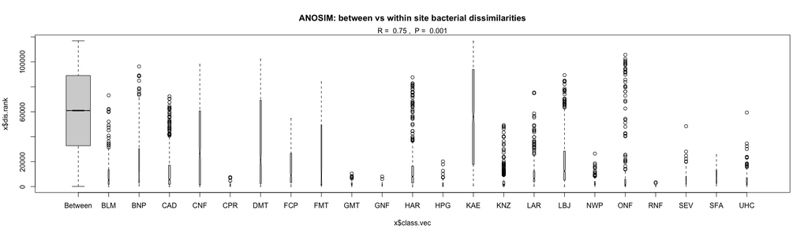

### 3.3.2 Fun

```r
Fun_Site.anosim <- with(phylo2vegan_sd(Fun_wholecommunity), anosim(Fun_wc_sorensen_distmat, Site))
Fun_Site.anosim
```

```
##
## Call:
## anosim(x = Fun_wc_sorensen_distmat, grouping = Site)
## Dissimilarity: user supplied square matrix
##
## ANOSIM statistic R: 0.6272
##       Significance: 0.001
##
## Permutation: free
## Number of permutations: 999
```

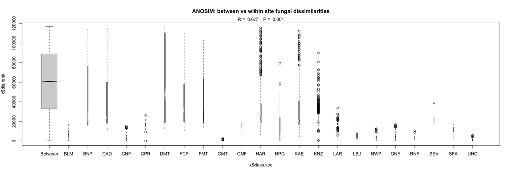

# 4 Tables: alpha beta gamma diversity of sites

## 4.1 Bac

```r
Bac_gamma_Site.dfclean<-Bac_gamma_Site.df[,c(1:8,11)]
Bac_gamma_Site.dfclean$`Gamma (# total unique OTUs)`<-prettyNum(Bac_gamma_Site.dfclean$`Gamma (# total unique OTUs)`, big.mark=",")

Bac_gamma_Site.dfclean$`Observed mean 𝝰`<-prettyNum(Bac_gamma_Site.dfclean$`Observed mean 𝝰`, big.mark=",")

Bac_gamma_Site.dfclean%>% kbl(caption = "Bacteria: alpha beta gamma diversity of sites",
            align = 'c'
      # col.names = c("Number of OTUs","Number of samples")
      # ,format.args = list(format(c(Fun_gamma_Site.df[,4]),big.mark = ','))
      ) %>% kable_styling() %>%
  scroll_box(width = "95%", height = "500px")
```

Table 4.1: Bacteria: alpha beta gamma diversity of sites

| Site | n (# of samples per site) | # of grass hosts per site | Gamma (# total unique OTUs) | Gamma / n | Observed mean 𝝰 | mean prop. of gamma detected per sample | SD prop. of gamma detected per sample | BetaDisp |
| --- | --- | --- | --- | --- | --- | --- | --- | --- |
| BLM | 23 | 2 | 4,689 | 203.9 | 924.7 | 0.197 | 0.029 | 0.4160 |
| BNP | 15 | 2 | 4,547 | 303.1 | 964.1 | 0.212 | 0.033 | 0.4380 |
| CAD | 38 | 4 | 8,620 | 226.8 | 1,419.1 | 0.165 | 0.031 | 0.4190 |
| CNF | 27 | 3 | 5,427 | 201.0 | 931.7 | 0.172 | 0.041 | 0.4509 |
| CPR | 11 | 1 | 2,719 | 247.2 | 814.4 | 0.300 | 0.045 | 0.3763 |
| DMT | 26 | 3 | 5,801 | 223.1 | 942.7 | 0.163 | 0.022 | 0.4599 |
| FCP | 27 | 3 | 6,362 | 235.6 | 1,154.5 | 0.181 | 0.026 | 0.4302 |
| FMT | 15 | 2 | 4,076 | 271.7 | 922.6 | 0.226 | 0.026 | 0.4410 |
| GMT | 19 | 2 | 4,362 | 229.6 | 1,010.6 | 0.232 | 0.034 | 0.3890 |
| GNF | 7 | 1 | 2,711 | 387.3 | 964.9 | 0.356 | 0.030 | 0.3820 |
| HAR | 37 | 4 | 6,631 | 179.2 | 1,058.9 | 0.160 | 0.028 | 0.4251 |
| HPG | 15 | 2 | 4,043 | 269.5 | 1,061.3 | 0.263 | 0.035 | 0.3778 |
| KAE | 32 | 3 | 6,909 | 215.9 | 875.5 | 0.127 | 0.061 | 0.5076 |
| KNZ | 42 | 4 | 7,892 | 187.9 | 1,390.3 | 0.176 | 0.019 | 0.3898 |
| LAR | 27 | 3 | 4,516 | 167.3 | 785.2 | 0.174 | 0.032 | 0.4232 |
| LBJ | 34 | 3 | 7,876 | 231.6 | 1,217.4 | 0.155 | 0.026 | 0.4421 |
| NWP | 20 | 2 | 5,964 | 298.2 | 1,325.1 | 0.222 | 0.031 | 0.3957 |
| ONF | 22 | 2 | 5,569 | 253.1 | 1,127.8 | 0.203 | 0.034 | 0.4041 |
| RNF | 6 | 1 | 2,517 | 419.5 | 1,007.5 | 0.400 | 0.055 | 0.3596 |
| SEV | 10 | 2 | 2,505 | 250.5 | 712.3 | 0.284 | 0.031 | 0.4091 |
| SFA | 10 | 1 | 5,456 | 545.6 | 1,471.5 | 0.270 | 0.021 | 0.4193 |
| UHC | 21 | 2 | 8,020 | 381.9 | 1,711.6 | 0.213 | 0.021 | 0.4011 |

## 4.2 Fun

```r
Fun_gamma_Site.dfclean<-Fun_gamma_Site.df[,c(1:8,11)]
Fun_gamma_Site.dfclean$`Gamma (# total unique OTUs)`<-prettyNum(Fun_gamma_Site.dfclean$`Gamma (# total unique OTUs)`, big.mark=",")

Fun_gamma_Site.dfclean$`Observed mean 𝝰`<-prettyNum(Fun_gamma_Site.dfclean$`Observed mean 𝝰`, big.mark=",")

Fun_gamma_Site.dfclean%>% kbl(caption = "Fungi: alpha beta gamma diversity of sites",
            align = 'c'
      # col.names = c("Number of OTUs","Number of samples")
      # ,format.args = list(format(c(Fun_gamma_Site.df[,4]),big.mark = ','))
      ) %>% kable_styling() %>%
  scroll_box(width = "95%", height = "500px")
```

Table 4.2: Fungi: alpha beta gamma diversity of sites

| Site | n (# of samples per site) | # of grass hosts per site | Gamma (# total unique OTUs) | Gamma / n | Observed mean 𝝰 | mean prop. of gamma detected per sample | SD prop. of gamma detected per sample | BetaDisp |
| --- | --- | --- | --- | --- | --- | --- | --- | --- |
| BLM | 23 | 2 | 983 | 42.7 | 181.3 | 0.184 | 0.029 | 0.6057 |
| BNP | 15 | 2 | 633 | 42.2 | 83.2 | 0.131 | 0.040 | 0.7496 |
| CAD | 38 | 4 | 1,341 | 35.3 | 120 | 0.090 | 0.021 | 0.7428 |
| CNF | 27 | 3 | 923 | 34.2 | 173.3 | 0.188 | 0.019 | 0.5813 |
| CPR | 11 | 1 | 430 | 39.1 | 94.1 | 0.219 | 0.031 | 0.6723 |
| DMT | 26 | 3 | 1,044 | 40.2 | 93.3 | 0.089 | 0.024 | 0.7698 |
| FCP | 27 | 3 | 1,169 | 43.3 | 120.5 | 0.103 | 0.030 | 0.7479 |
| FMT | 15 | 2 | 522 | 34.8 | 71.4 | 0.137 | 0.023 | 0.7450 |
| GMT | 19 | 2 | 646 | 34.0 | 189 | 0.293 | 0.022 | 0.5467 |
| GNF | 7 | 1 | 256 | 36.6 | 74 | 0.289 | 0.059 | 0.6628 |
| HAR | 37 | 4 | 1,315 | 35.5 | 129.4 | 0.098 | 0.025 | 0.7317 |
| HPG | 15 | 2 | 717 | 47.8 | 165.3 | 0.230 | 0.052 | 0.6494 |
| KAE | 32 | 3 | 1,202 | 37.6 | 119.5 | 0.099 | 0.018 | 0.7217 |
| KNZ | 42 | 4 | 1,337 | 31.8 | 141 | 0.105 | 0.020 | 0.7067 |
| LAR | 27 | 3 | 694 | 25.7 | 90.8 | 0.131 | 0.027 | 0.6819 |
| LBJ | 34 | 3 | 1,442 | 42.4 | 218.6 | 0.152 | 0.025 | 0.5967 |
| NWP | 20 | 2 | 1,007 | 50.4 | 219.3 | 0.218 | 0.021 | 0.5859 |
| ONF | 22 | 2 | 1,068 | 48.5 | 203.3 | 0.190 | 0.019 | 0.5951 |
| RNF | 6 | 1 | 443 | 73.8 | 179.7 | 0.406 | 0.035 | 0.5836 |
| SEV | 10 | 2 | 379 | 37.9 | 73.5 | 0.194 | 0.055 | 0.7140 |
| SFA | 10 | 1 | 817 | 81.7 | 188.4 | 0.231 | 0.051 | 0.6288 |
| UHC | 21 | 2 | 936 | 44.6 | 212 | 0.226 | 0.024 | 0.5630 |

# 5 Statistical testing

## 5.1 normality and density plot of site gamma

### 5.1.1 Bac

```r
shapiro.test(Bac_gamma_Site.df$`Gamma (# total unique OTUs)`)
```

```
##
##  Shapiro-Wilk normality test
##
## data:  Bac_gamma_Site.df$`Gamma (# total unique OTUs)`
## W = 0.95319, p-value = 0.3648
```

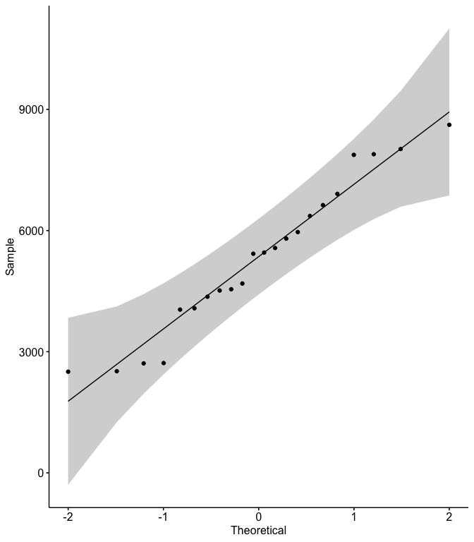

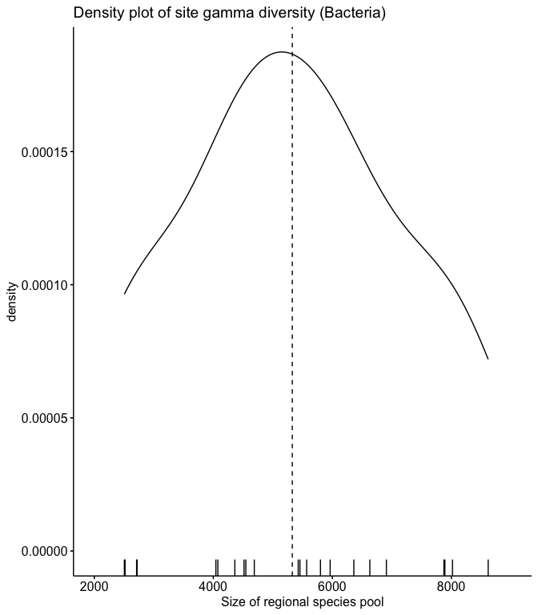

```r
ggqqplot(Bac_gamma_Site.df$`Gamma (# total unique OTUs)`)
ggdensity(Bac_gamma_Site.df$`Gamma (# total unique OTUs)`,
          main = "Density plot of site gamma diversity (Bacteria)",
          xlab = "Size of regional species pool",
          add = "mean",xlim = c(2000, 9000),rug=T)
```

### 5.1.2 Fun

```r
shapiro.test(Fun_gamma_Site.df$`Gamma (# total unique OTUs)`)
```

```
##
##  Shapiro-Wilk normality test
##
## data:  Fun_gamma_Site.df$`Gamma (# total unique OTUs)`
## W = 0.96265, p-value = 0.5447
```

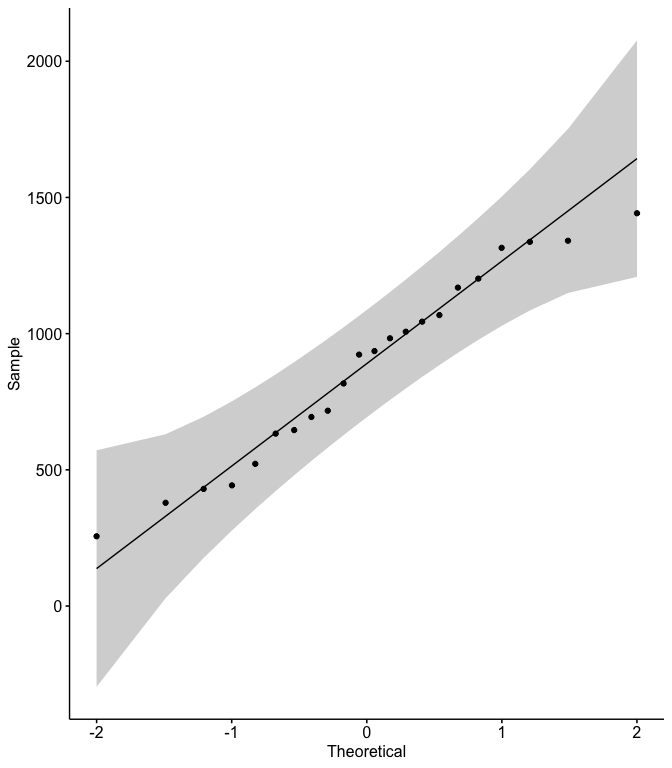

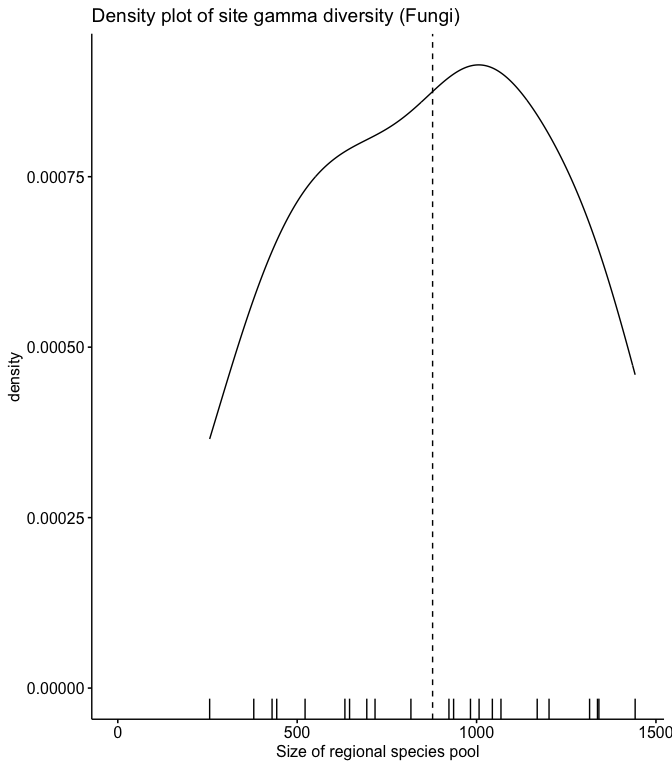

```r
ggqqplot(Fun_gamma_Site.df$`Gamma (# total unique OTUs)`)
ggdensity(Fun_gamma_Site.df$`Gamma (# total unique OTUs)`,
          main = "Density plot of site gamma diversity (Fungi)",
          xlab = "Size of regional species pool",
          add = "mean",xlim = c(0, 1450),rug=T)
```

## 5.2 kruskal.tests

[in-progress]

### 5.2.1 Predictor: Size of Contra-kingdom Regional Species Pool (Response contra-kindgom gamma)

Does bacterial gamma influence fungal gamma? yes

```r
# does fun gamma vary by gamma of bac
kruskal.test(fwc_alpha_Site$Fun_gamma_Site~bwc_alpha_Site$Bac_gamma_Site)
```

```
##
##  Kruskal-Wallis rank sum test
##
## data:  fwc_alpha_Site$Fun_gamma_Site by bwc_alpha_Site$Bac_gamma_Site
## Kruskal-Wallis chi-squared = 483, df = 21, p-value < 2.2e-16
```

```
- after normalizing by nsamples per site?
```

```r
# does fun gamma vary by gamma of bac
kruskal.test(fwc_alpha_Site$Fun_Gamma_over_n~bwc_alpha_Site$Bac_Gamma_over_n)
```

```
##
##  Kruskal-Wallis rank sum test
##
## data:  fwc_alpha_Site$Fun_Gamma_over_n by bwc_alpha_Site$Bac_Gamma_over_n
## Kruskal-Wallis chi-squared = 483, df = 21, p-value < 2.2e-16
```

```
    - still yes
```

Does fungal gamma influence bacterial gamma? yes

```r
# does bac gamma vary by gamma of fun
kruskal.test(bwc_alpha_Site$Bac_gamma_Site~fwc_alpha_Site$Fun_gamma_Site)
```

```
##
##  Kruskal-Wallis rank sum test
##
## data:  bwc_alpha_Site$Bac_gamma_Site by fwc_alpha_Site$Fun_gamma_Site
## Kruskal-Wallis chi-squared = 483, df = 21, p-value < 2.2e-16
```

```
- after normalizing by nsamples per site?
```

```r
# does bac gamma vary by gamma of fun
kruskal.test(bwc_alpha_Site$Bac_Gamma_over_n~fwc_alpha_Site$Fun_Gamma_over_n)
```

```
##
##  Kruskal-Wallis rank sum test
##
## data:  bwc_alpha_Site$Bac_Gamma_over_n by fwc_alpha_Site$Fun_Gamma_over_n
## Kruskal-Wallis chi-squared = 483, df = 21, p-value < 2.2e-16
```

```
    - still yes
```

### 5.2.2 Predictor: Contra-kingdom Richness (Response Richness)

Does bacterial richness influence fungal richness? no

```r
# does sample alpha vary by Observed of bac
kruskal.test(fwc_alpha_Site$Observed~bwc_alpha_Site$Observed)
```

```
##
##  Kruskal-Wallis rank sum test
##
## data:  fwc_alpha_Site$Observed by bwc_alpha_Site$Observed
## Kruskal-Wallis chi-squared = 404.16, df = 390, p-value = 0.2999
```

Does fungal richness influence bacterial richness? YES

```r
# does bac sample alpha vary by Observed of fun
kruskal.test(bwc_alpha_Site$Observed~fwc_alpha_Site$Observed)
```

```
##
##  Kruskal-Wallis rank sum test
##
## data:  bwc_alpha_Site$Observed by fwc_alpha_Site$Observed
## Kruskal-Wallis chi-squared = 236.23, df = 184, p-value = 0.005623
```

### 5.2.3 Predictor: # of grass hosts per site

```r
# does sample alpha vary by ngrass_persite
kruskal.test(fwc_alpha_Site$Observed~fwc_alpha_Site$ngrass_persite)
```

```
##
##  Kruskal-Wallis rank sum test
##
## data:  fwc_alpha_Site$Observed by fwc_alpha_Site$ngrass_persite
## Kruskal-Wallis chi-squared = 38.431, df = 3, p-value = 2.291e-08
```

```r
# does site gamma vary by ngrass_persite
kruskal.test(Fun_gamma_Site2[,1]~Fun_gamma_Site3temp$ngrass_persite)
```

```
##
##  Kruskal-Wallis rank sum test
##
## data:  Fun_gamma_Site2[, 1] by Fun_gamma_Site3temp$ngrass_persite
## Kruskal-Wallis chi-squared = 3.1963, df = 3, p-value = 0.3623
```

```r
# does site gamma/n vary by ngrass_persite
kruskal.test(Fun_gamma_Site3temp$`Gamma_over_n`~Fun_gamma_Site3temp$ngrass_persite)
```

```
##
##  Kruskal-Wallis rank sum test
##
## data:  Fun_gamma_Site3temp$Gamma_over_n by Fun_gamma_Site3temp$ngrass_persite
## Kruskal-Wallis chi-squared = 5.9091, df = 3, p-value = 0.1161
```

```r
# does site obs_mean_alpha vary by ngrass_persite
kruskal.test(Fun_gamma_Site.df$`Observed mean 𝝰`~Fun_gamma_Site.df$`# of grass hosts per site`)
```

```
##
##  Kruskal-Wallis rank sum test
##
## data:  Fun_gamma_Site.df$`Observed mean 𝝰` by Fun_gamma_Site.df$`# of grass hosts per site`
## Kruskal-Wallis chi-squared = 0.59157, df = 3, p-value = 0.8984
```

```r
# does site mean prop. of gamma detected per sample vary by ngrass_persite YES
kruskal.test(Fun_gamma_Site.df$`mean prop. of gamma detected per sample`~Fun_gamma_Site.df$`# of grass hosts per site`)
```

```
##
##  Kruskal-Wallis rank sum test
##
## data:  Fun_gamma_Site.df$`mean prop. of gamma detected per sample` by Fun_gamma_Site.df$`# of grass hosts per site`
## Kruskal-Wallis chi-squared = 14.787, df = 3, p-value = 0.002008
```

# 6 aov gamma

# 7 plot alpha obs v exp

```r
ggplot(aes(x=Bac_gamma_Site.df$`Observed mean 𝝰`,y=Fun_gamma_Site.df$`Observed mean 𝝰`,color=Site),data=Bac_gamma_Site.df)+
  geom_point(size=3)+
  scale_color_manual(values = latlong_cols)+
  # geom_abline(aes(slope = 1,intercept=0),data=Fun_gamma_Site.df, color="black")+
 labs(y="Fungi: Obs mean alpha",x="Bacteria: Obs mean alpha",color="Site")+
  theme_bw() +
  theme(legend.position="right",
    axis.text = element_text(color="black", size=10),
    axis.title = element_text(color="black", size=12),
    legend.text = element_text(color="black", size=8),legend.title = element_text(color="black", size=10),
    plot.background = element_blank(),panel.border = element_rect(colour = "black", fill=NA, linewidth=.75),
    panel.grid.major = element_blank(),panel.grid.minor = element_blank(),panel.background = element_blank())

ggplot(aes(x=Bac_gamma_Site.df$`Observed mean 𝝰`,y=Bac_gamma_Site.df$`Expected mean 𝝰`,color=Site),data=Bac_gamma_Site.df)+
  geom_point(size=3)+
  scale_color_manual(values = latlong_cols)+
  scale_x_continuous(limits = c(0,2000))+
  scale_y_continuous(limits = c(0,750))+
  geom_abline(aes(slope = 1,intercept=0),data=Fun_gamma_Site.df, color="black")+
  labs(y="Gamma_over_n",x="Observed mean alpha",color="Site",title = "Bacteria")+
  theme_bw() +
  theme(legend.position="right",
    axis.text = element_text(color="black", size=10),
    axis.title = element_text(color="black", size=12),
    legend.text = element_text(color="black", size=8),legend.title = element_text(color="black", size=10),
    plot.background = element_blank(),panel.border = element_rect(colour = "black", fill=NA, linewidth=.75),
    panel.grid.major = element_blank(),panel.grid.minor = element_blank(),panel.background = element_blank())


ggplot(aes(x=Fun_gamma_Site.df$`Observed mean 𝝰`,y=Fun_gamma_Site.df$`Expected mean 𝝰`,color=Site),data=Fun_gamma_Site.df)+
  geom_point(size=3)+
  scale_x_continuous(limits = c(0,300))+
  scale_y_continuous(limits = c(0,100))+
  scale_color_manual(values = latlong_cols)+
  geom_abline(aes(slope = 1,intercept=0),data=Fun_gamma_Site.df, color="black")+
  labs(y="Gamma_over_n",x="Observed mean alpha",color="Site",title = "Fungi")+
  theme_bw() +
  theme(legend.position="right",
    axis.text = element_text(color="black", size=10),
    axis.title = element_text(color="black", size=12),
    legend.text = element_text(color="black", size=8),legend.title = element_text(color="black", size=10),
    plot.background = element_blank(),panel.border = element_rect(colour = "black", fill=NA, linewidth=.75),
    panel.grid.major = element_blank(),panel.grid.minor = element_blank(),panel.background = element_blank())

ggplot(aes(x=Fun_gamma_Site.df$`Observed mean 𝝰`,y=Fun_gamma_Site.df$`Expected mean 𝝰`,color=Site),data=Fun_gamma_Site.df)+
  geom_point(size=3)+
  scale_x_continuous(limits = c(0,300))+
  scale_y_continuous(limits = c(0,100))+
  scale_color_manual(values = latlong_cols)+
  geom_abline(aes(slope = 1,intercept=0),data=Fun_gamma_Site.df, color="black")+
  labs(y="Gamma_over_n",x="Observed mean alpha",color="Site",title = "Fungi")+
  theme_bw() +
  theme(legend.position="right",
    axis.text = element_text(color="black", size=10),
    axis.title = element_text(color="black", size=12),
    legend.text = element_text(color="black", size=8),legend.title = element_text(color="black", size=10),
    plot.background = element_blank(),panel.border = element_rect(colour = "black", fill=NA, linewidth=.75),
    panel.grid.major = element_blank(),panel.grid.minor = element_blank(),panel.background = element_blank())
```

[output not shown]

# 8 beta disp by grass landscape